# Final Report for Intro to Data Science: Steam Games

## Group Members

- Randy Koliha
- Isaiah Sarria
- Owen Telis
- John Levitt

# Introduction

Steam is a popular, online video game distributor with many other complementing features. Steams hosts community discussion threads, access to download community-made modifications to games sold on the platform, social media-like user profiles and friends lists that displays the users overall or recent video game activity, and sales events which are based on holidays or unique themes.

We want to analyze a dataset regarding Steam games to dive deep into the behavior of gamers on the platform.

# Packages

Loading any needed packages.

```r
library(tidyverse)
library(scales)
library(directlabels)
```

# The Dataset

The games.csv dataset has data collected for games on the popular game license selling platform, Steam, over the months from the years July 2012- Febuary 2021. The data set has records of 1258 games (also includes other miscellaneous pieces of software), and includes their titles, monthly player peaks, monthly average players at the same time, monthly gains/losses of players compared to the previous month, and the percentage of how closely the average players approach the peak.

## Running the data & cleaning up

```r
# Storing dataset in `games`
games <- read.csv("https://raw.githubusercontent.com/rfordatascience/tidytuesday/master/data/2021/2021-03-16/games.csv")

#cleaning it up

games <- games %>%
  mutate( number_of_month = match(games[1:83631,3], month.name) ) %>%
  select(gamename,year,number_of_month,everything()) %>%
  arrange(desc(year), number_of_month)
  games
```

| gamename | year | number_of_month | month | avg | gain | peak | avg_peak_perc |
| --- | --- | --- | --- | --- | --- | --- | --- |
| Counter-Strike: Global Offensive | 2021 | 1 | January | 743209.66 | 25405.91 | 1124553 | 66.0893% |
| Dota 2 | 2021 | 1 | January | 432671.65 | 10119.33 | 694613 | 62.2896% |
| PLAYERUNKNOWN'S BATTLEGROUNDS | 2021 | 1 | January | 201247.19 | 12013.61 | 451998 | 44.5239% |
| Apex Legends | 2021 | 1 | January | 71766.74 | 7296.99 | 129928 | 55.2358% |
| Rust | 2021 | 1 | January | 142117.25 | 80945.60 | 244394 | 58.1509% |
| Team Fortress 2 | 2021 | 1 | January | 83148.17 | 724.66 | 111102 | 74.8395% |
| Grand Theft Auto V | 2021 | 1 | January | 101250.59 | -5663.68 | 184941 | 54.7475% |
| Tom Clancy's Rainbow Six Siege | 2021 | 1 | January | 77717.42 | 6995.92 | 123637 | 62.8594% |
| Rocket League | 2021 | 1 | January | 59449.16 | -6315.92 | 112482 | 52.8522% |
| Path of Exile | 2021 | 1 | January | 47685.61 | 34987.98 | 157091 | 30.3554% |

[output cut: 9990 more lines]

# Data Exploration

```r
summary(games)
```

```
##    gamename              year      number_of_month     month
##  Length:83631       Min.   :2012   Min.   : 1.000   Length:83631
##  Class :character   1st Qu.:2016   1st Qu.: 3.000   Class :character
##  Mode  :character   Median :2018   Median : 7.000   Mode  :character
##                     Mean   :2017   Mean   : 6.546
##                     3rd Qu.:2019   3rd Qu.:10.000
##                     Max.   :2021   Max.   :12.000
##
##       avg                 gain                peak         avg_peak_perc
##  Min.   :      0.0   Min.   :-250249.0   Min.   :      0   Length:83631
##  1st Qu.:     53.1   1st Qu.:    -38.2   1st Qu.:    137   Class :character
##  Median :    203.1   Median :     -1.6   Median :    500   Mode  :character
##  Mean   :   2765.7   Mean   :    -10.3   Mean   :   5470
##  3rd Qu.:    764.0   3rd Qu.:     22.2   3rd Qu.:   1727
##  Max.   :1584886.8   Max.   : 426446.1   Max.   :3236027
##                      NA's   :1258
```

## How many games are in the data set

```r
# Finding the distinct number of `gamenames`
dist_g <- games %>%
  distinct(gamename)

dist_g
```

| gamename |
| --- |
| Counter-Strike: Global Offensive |
| Dota 2 |
| PLAYERUNKNOWN'S BATTLEGROUNDS |
| Apex Legends |
| Rust |
| Team Fortress 2 |
| Grand Theft Auto V |
| Tom Clancy's Rainbow Six Siege |
| Rocket League |
| Path of Exile |

[output cut: 1248 more lines]

```r
# in alpha order

 dist_g_alpha <- games %>%
  distinct(gamename) %>%
  arrange(gamename)

dist_g_alpha
```

| gamename |
| --- |
| 8 Heroes of the Three Kingdoms 8 |
| (PathOfWuxia) |
| (Gujian3) |
| Bloody Spell |
| The Scroll Of Taiwu |
| /-1v5(Notes of Soul) |
| ~ Hidden Star in Four Seasons. |
| (MahjongSoul) |
| 100% Orange Juice |
| 12 is Better Than 6 |

[output cut: 1248 more lines]

## Question 1: Do all games lose popularity overtime? How do multiplayer and single player titles differ?

### Case 1: What if the game is given out for free after its been for sale.

```r
g_payday <- games %>%
  filter(gamename == "PAYDAY 2") %>%
  filter(year %in% c(2012:2021)) %>%
  mutate(label = if_else(number_of_month == max(number_of_month), as.character(year), NA_character_))
g_payday
```

| gamename | year | number_of_month | month | avg | gain | peak | avg_peak_perc | label |
| --- | --- | --- | --- | --- | --- | --- | --- | --- |
| PAYDAY 2 | 2021 | 1 | January | 29201.19 | -841.71 | 54841 | 53.247% | NA |
| PAYDAY 2 | 2021 | 2 | February | 26164.82 | -3036.36 | 44327 | 59.0268% | NA |
| PAYDAY 2 | 2020 | 1 | January | 20294.08 | -3999.36 | 39376 | 51.5392% | NA |
| PAYDAY 2 | 2020 | 2 | February | 18555.42 | -1738.67 | 31830 | 58.2954% | NA |
| PAYDAY 2 | 2020 | 3 | March | 21027.94 | 2472.53 | 36273 | 57.9713% | NA |
| PAYDAY 2 | 2020 | 4 | April | 25319.54 | 4291.60 | 39419 | 64.2318% | NA |
| PAYDAY 2 | 2020 | 5 | May | 35338.15 | 10018.62 | 61728 | 57.2482% | NA |
| PAYDAY 2 | 2020 | 6 | June | 29398.47 | -5939.69 | 56703 | 51.8464% | NA |
| PAYDAY 2 | 2020 | 7 | July | 30649.83 | 1251.36 | 48473 | 63.2307% | NA |
| PAYDAY 2 | 2020 | 8 | August | 31718.94 | 1069.12 | 46799 | 67.777% | NA |

[output cut: 93 more lines]

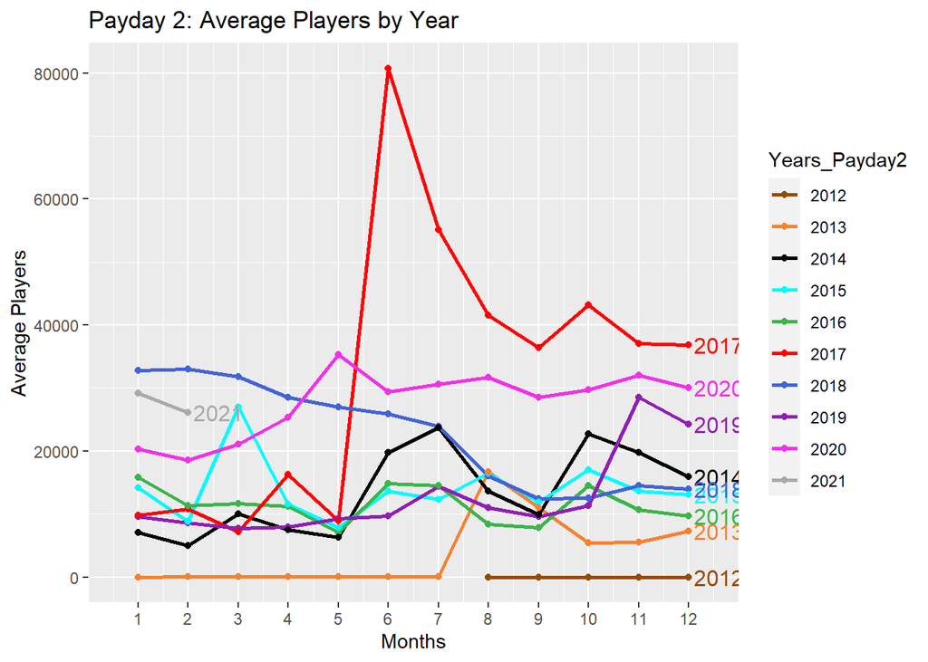

```r
#makes the PAYDAY 2 dataframe

Years_Payday2 <- as.factor(g_payday$year)
ggplot(g_payday,aes(x = number_of_month,y = avg, group = year, color = Years_Payday2)) +
geom_line(size = 1) +
geom_point()+
scale_x_continuous(breaks = seq(1, 12, by = 1),expand=c(0, 1))+
geom_dl(aes(label = year), method = list(dl.trans(x = x + 0.1), "last.points", cex = 1)) +
scale_colour_manual(values=c("#964B00","#f58231","#030000", "#00FBFE", "#3cb44b", "#FF0004", "#4363d8", "#911eb4", "#f032e6", "#a9a9a9" )) +
  xlab("Months")+
  ylab("Average Players") +
  labs(title = "Payday 2: Average Players by Year")
```

```r
#auto color pallet if + scale manual is removed
```

[figure not shown]

### Case 2: Multiplayer/Esports Titles

```r
g_pubg <- games %>%
  filter(gamename == "PLAYERUNKNOWN'S BATTLEGROUNDS") %>%
  filter(year %in% c(2017:2021)) %>%
  mutate(label = if_else(number_of_month == max(number_of_month), as.character(year), NA_character_))
g_pubg
```

| gamename | year | number_of_month | month | avg | gain | peak | avg_peak_perc | label |
| --- | --- | --- | --- | --- | --- | --- | --- | --- |
| PLAYERUNKNOWN'S BATTLEGROUNDS | 2021 | 1 | January | 201247.19 | 12013.61 | 451998 | 44.5239% | NA |
| PLAYERUNKNOWN'S BATTLEGROUNDS | 2021 | 2 | February | 198957.52 | -2289.67 | 447390 | 44.4707% | NA |
| PLAYERUNKNOWN'S BATTLEGROUNDS | 2020 | 1 | January | 275363.04 | -33082.41 | 645414 | 42.6646% | NA |
| PLAYERUNKNOWN'S BATTLEGROUNDS | 2020 | 2 | February | 257584.32 | -17778.72 | 606689 | 42.4574% | NA |
| PLAYERUNKNOWN'S BATTLEGROUNDS | 2020 | 3 | March | 228467.17 | -29117.16 | 562028 | 40.6505% | NA |
| PLAYERUNKNOWN'S BATTLEGROUNDS | 2020 | 4 | April | 242847.28 | 14380.11 | 913075 | 26.5966% | NA |
| PLAYERUNKNOWN'S BATTLEGROUNDS | 2020 | 5 | May | 243258.78 | 411.51 | 553121 | 43.9793% | NA |
| PLAYERUNKNOWN'S BATTLEGROUNDS | 2020 | 6 | June | 230329.74 | -12929.04 | 546359 | 42.1572% | NA |
| PLAYERUNKNOWN'S BATTLEGROUNDS | 2020 | 7 | July | 211700.30 | -18629.44 | 469568 | 45.0841% | NA |
| PLAYERUNKNOWN'S BATTLEGROUNDS | 2020 | 8 | August | 192492.61 | -19207.70 | 443390 | 43.4138% | NA |

[output cut: 38 more lines]

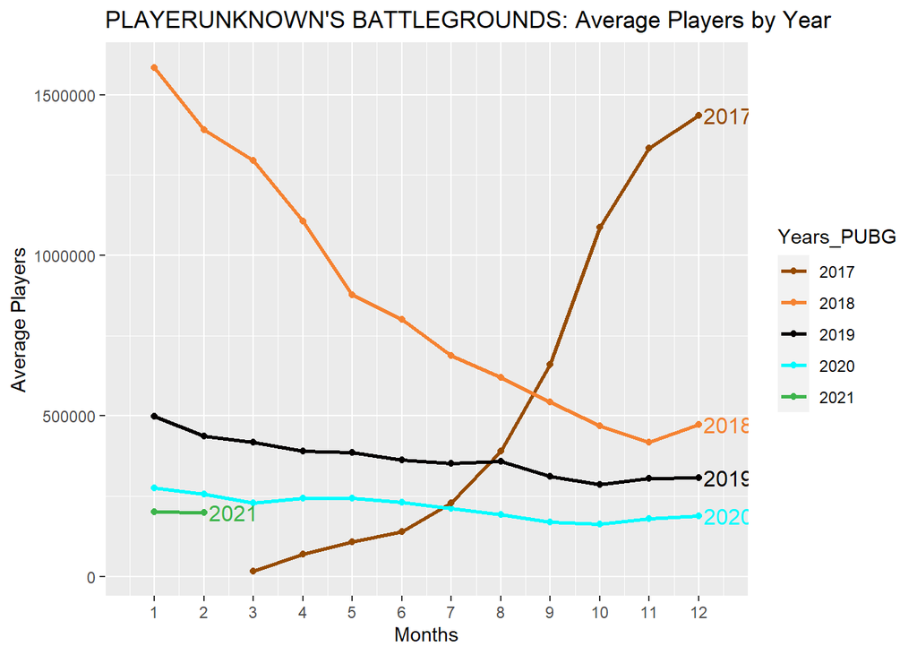

```r
Years_PUBG <- as.factor(g_pubg$year)
ggplot(g_pubg,aes(x = number_of_month,y = avg, group = year, color = Years_PUBG)) +
geom_line(size = 1) +
geom_point()+
scale_x_continuous(breaks = seq(1, 12, by = 1),expand=c(0, 1))+
geom_dl(aes(label = year), method = list(dl.trans(x = x + 0.1), "last.points", cex = 1)) +
scale_colour_manual(values=c("#964B00","#f58231","#030000", "#00FBFE", "#3cb44b",  "#a9a9a9" )) +
  xlab("Months")+
  ylab("Average Players") +
  labs(title = "PLAYERUNKNOWN'S BATTLEGROUNDS: Average Players by Year")
```

```r
g_csgo <- games %>%
  filter(gamename == "Counter-Strike: Global Offensive") %>%
  filter(year %in% c(2012:2021)) %>%
  mutate(label = if_else(number_of_month == max(number_of_month), as.character(year), NA_character_))
g_csgo
```

| gamename | year | number_of_month | month | avg | gain | peak | avg_peak_perc | label |
| --- | --- | --- | --- | --- | --- | --- | --- | --- |
| Counter-Strike: Global Offensive | 2021 | 1 | January | 743209.66 | 25405.91 | 1124553 | 66.0893% | NA |
| Counter-Strike: Global Offensive | 2021 | 2 | February | 741013.24 | -2196.42 | 1123485 | 65.9567% | NA |
| Counter-Strike: Global Offensive | 2020 | 1 | January | 501196.00 | 44494.44 | 817229 | 61.3287% | NA |
| Counter-Strike: Global Offensive | 2020 | 2 | February | 543979.15 | 42783.15 | 916996 | 59.3219% | NA |
| Counter-Strike: Global Offensive | 2020 | 3 | March | 671033.29 | 127054.13 | 1145972 | 58.5558% | NA |
| Counter-Strike: Global Offensive | 2020 | 4 | April | 857604.22 | 186570.94 | 1305714 | 65.6809% | NA |
| Counter-Strike: Global Offensive | 2020 | 5 | May | 768795.25 | -88808.97 | 1193359 | 64.4228% | NA |
| Counter-Strike: Global Offensive | 2020 | 6 | June | 671647.46 | -97147.79 | 1009467 | 66.5349% | NA |
| Counter-Strike: Global Offensive | 2020 | 7 | July | 625900.81 | -45746.65 | 857560 | 72.9862% | NA |
| Counter-Strike: Global Offensive | 2020 | 8 | August | 639957.66 | 14056.85 | 925348 | 69.1586% | NA |

[output cut: 94 more lines]

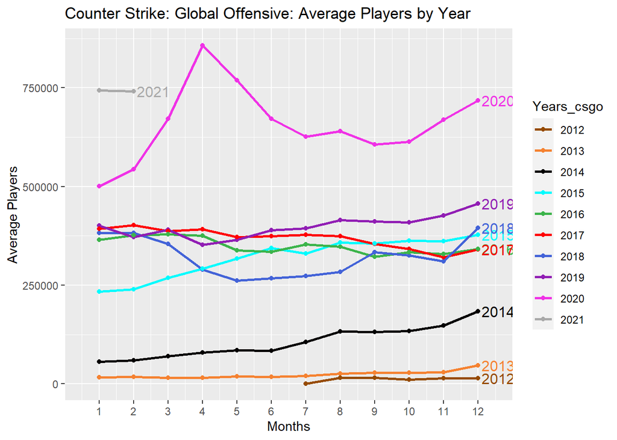

```r
Years_csgo <- as.factor(g_csgo$year)
ggplot(g_csgo,aes(x = number_of_month,y = avg, group = year, color = Years_csgo)) +
geom_line(size = 1) +
geom_point()+
scale_x_continuous(breaks = seq(1, 12, by = 1),expand=c(0, 1))+
geom_dl(aes(label = year), method = list(dl.trans(x = x + 0.1), "last.points", cex = 1)) +
scale_colour_manual(values=c("#964B00","#f58231","#030000", "#00FBFE", "#3cb44b", "#FF0004", "#4363d8", "#911eb4", "#f032e6", "#a9a9a9" )) +
  xlab("Months")+
  ylab("Average Players") +
  labs(title = "Counter Strike: Global Offensive: Average Players by Year")
```

```r
g_gtav <- games %>%
  filter(gamename == "Grand Theft Auto V") %>%
  filter(year %in% c(2012:2021)) %>%
  mutate(label = if_else(number_of_month == max(number_of_month), as.character(year), NA_character_))
g_gtav
```

| gamename | year | number_of_month | month | avg | gain | peak | avg_peak_perc | label |
| --- | --- | --- | --- | --- | --- | --- | --- | --- |
| Grand Theft Auto V | 2021 | 1 | January | 101250.59 | -5663.68 | 184941 | 54.7475% | NA |
| Grand Theft Auto V | 2021 | 2 | February | 90647.64 | -10602.95 | 146438 | 61.9017% | NA |
| Grand Theft Auto V | 2020 | 1 | January | 111300.20 | 13522.51 | 214796 | 51.8167% | NA |
| Grand Theft Auto V | 2020 | 2 | February | 142724.48 | 31424.28 | 267360 | 53.3829% | NA |
| Grand Theft Auto V | 2020 | 3 | March | 116386.37 | -26338.11 | 209493 | 55.5562% | NA |
| Grand Theft Auto V | 2020 | 4 | April | 126086.73 | 9700.36 | 243284 | 51.827% | NA |
| Grand Theft Auto V | 2020 | 5 | May | 141369.88 | 15283.15 | 260562 | 54.2558% | NA |
| Grand Theft Auto V | 2020 | 6 | June | 99752.85 | -41617.03 | 180302 | 55.3254% | NA |
| Grand Theft Auto V | 2020 | 7 | July | 83654.72 | -16098.13 | 134093 | 62.3856% | NA |
| Grand Theft Auto V | 2020 | 8 | August | 88398.36 | 4743.64 | 154677 | 57.1503% | NA |

[output cut: 61 more lines]

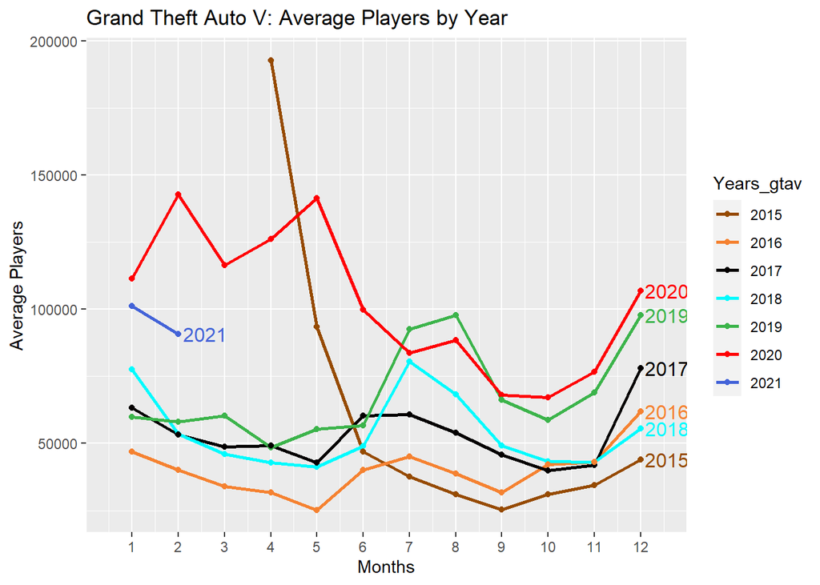

```r
Years_gtav <- as.factor(g_gtav$year)
ggplot(g_gtav,aes(x = number_of_month,y = avg, group = year, color = Years_gtav)) +
geom_line(size = 1) +
geom_point()+
scale_x_continuous(breaks = seq(1, 12, by = 1),expand=c(0, 1))+
geom_dl(aes(label = year), method = list(dl.trans(x = x + 0.1), "last.points", cex = 1)) +
scale_colour_manual(values=c("#964B00","#f58231","#030000", "#00FBFE", "#3cb44b", "#FF0004", "#4363d8", "#911eb4", "#f032e6", "#a9a9a9" )) +
  xlab("Months")+
  ylab("Average Players") +
  labs(title = "Grand Theft Auto V: Average Players by Year")
```

```r
g_dota2 <- games %>%
  filter(gamename == "Dota 2") %>%
  filter(year %in% c(2012:2021)) %>%
  mutate(label = if_else(number_of_month == max(number_of_month), as.character(year), NA_character_))
g_dota2
```

| gamename | year | number_of_month | month | avg | gain | peak | avg_peak_perc | label |
| --- | --- | --- | --- | --- | --- | --- | --- | --- |
| Dota 2 | 2021 | 1 | January | 432671.65 | 10119.33 | 694613 | 62.2896% | NA |
| Dota 2 | 2021 | 2 | February | 404832.13 | -27839.52 | 651615 | 62.1275% | NA |
| Dota 2 | 2020 | 1 | January | 378925.43 | -5254.32 | 616415 | 61.4725% | NA |
| Dota 2 | 2020 | 2 | February | 405978.65 | 27053.22 | 663812 | 61.1587% | NA |
| Dota 2 | 2020 | 3 | March | 437147.36 | 31168.71 | 743933 | 58.7617% | NA |
| Dota 2 | 2020 | 4 | April | 493300.27 | 56152.91 | 801121 | 61.5763% | NA |
| Dota 2 | 2020 | 5 | May | 484189.02 | -9111.25 | 793135 | 61.0475% | NA |
| Dota 2 | 2020 | 6 | June | 457184.42 | -27004.60 | 733294 | 62.3467% | NA |
| Dota 2 | 2020 | 7 | July | 450213.99 | -6970.43 | 712610 | 63.1782% | NA |
| Dota 2 | 2020 | 8 | August | 429717.12 | -20496.87 | 666138 | 64.5087% | NA |

[output cut: 94 more lines]

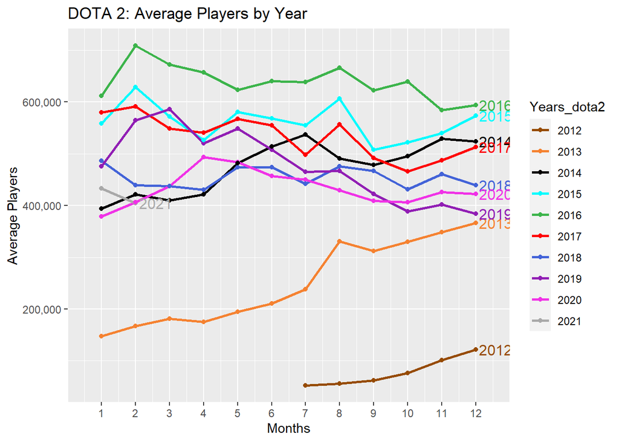

```r
Years_dota2 <- as.factor(g_dota2$year)
ggplot(g_dota2,aes(x = number_of_month,y = avg, group = year, color = Years_dota2)) +
geom_line(size = 1) +
geom_point()+
scale_x_continuous(breaks = seq(1, 12, by = 1),expand=c(0, 1))+
geom_dl(aes(label = year), method = list(dl.trans(x = x + 0.1), "last.points", cex = 1)) +
scale_colour_manual(values=c("#964B00","#f58231","#030000", "#00FBFE", "#3cb44b", "#FF0004", "#4363d8", "#911eb4", "#f032e6", "#a9a9a9" )) +
  xlab("Months")+
  ylab("Average Players") +
  scale_y_continuous(labels = comma) +
  labs(title = "DOTA 2: Average Players by Year")
```

> This data shows that many multiplayer games seem to gain player over time and often have their peak average players occur in a period signficantly after the launch of the game.

### Case 3: Single Player Titles

```r
g_fallout4 <- games %>%
  filter(gamename == "Fallout 4") %>%
  filter(year %in% c(2012:2021)) %>%
  mutate(label = if_else(number_of_month == max(number_of_month), as.character(year), NA_character_))
g_fallout4
```

| gamename | year | number_of_month | month | avg | gain | peak | avg_peak_perc | label |
| --- | --- | --- | --- | --- | --- | --- | --- | --- |
| Fallout 4 | 2021 | 1 | January | 15083.94 | 624.58 | 23877 | 63.1735% | NA |
| Fallout 4 | 2021 | 2 | February | 13773.15 | -1310.79 | 21274 | 64.7417% | NA |
| Fallout 4 | 2020 | 1 | January | 14376.51 | 397.28 | 23023 | 62.4441% | NA |
| Fallout 4 | 2020 | 2 | February | 13790.63 | -585.88 | 21988 | 62.7189% | NA |
| Fallout 4 | 2020 | 3 | March | 14345.23 | 554.60 | 24354 | 58.903% | NA |
| Fallout 4 | 2020 | 4 | April | 15986.54 | 1641.31 | 24455 | 65.3713% | NA |
| Fallout 4 | 2020 | 5 | May | 15136.06 | -850.47 | 23912 | 63.299% | NA |
| Fallout 4 | 2020 | 6 | June | 12924.14 | -2211.93 | 20948 | 61.6963% | NA |
| Fallout 4 | 2020 | 7 | July | 15148.35 | 2224.21 | 23204 | 65.2834% | NA |
| Fallout 4 | 2020 | 8 | August | 15216.79 | 68.44 | 24206 | 62.8637% | NA |

[output cut: 54 more lines]

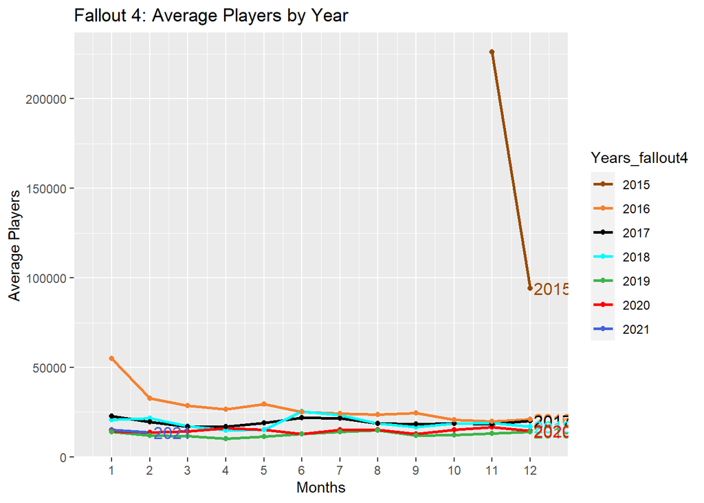

```r
Years_fallout4 <- as.factor(g_fallout4$year)
ggplot(g_fallout4,aes(x = number_of_month,y = avg, group = year, color = Years_fallout4)) +
geom_line(size = 1) +
geom_point()+
scale_x_continuous(breaks = seq(1, 12, by = 1),expand=c(0, 1))+
geom_dl(aes(label = year), method = list(dl.trans(x = x + 0.1), "last.points", cex = 1)) +
scale_colour_manual(values=c("#964B00","#f58231","#030000", "#00FBFE", "#3cb44b", "#FF0004", "#4363d8", "#911eb4", "#f032e6", "#a9a9a9" )) +
  xlab("Months")+
  ylab("Average Players") +
  labs(title = "Fallout 4: Average Players by Year")
```

```r
g_farcry5 <- games %>%
  filter(gamename == "Far Cry 5") %>%
  filter(year %in% c(2012:2021)) %>%
  mutate(label = if_else(number_of_month == max(number_of_month), as.character(year), NA_character_))
g_farcry5
```

| gamename | year | number_of_month | month | avg | gain | peak | avg_peak_perc | label |
| --- | --- | --- | --- | --- | --- | --- | --- | --- |
| Far Cry 5 | 2021 | 1 | January | 5499.41 | 1118.55 | 11476 | 47.921% | NA |
| Far Cry 5 | 2021 | 2 | February | 3396.95 | -2102.46 | 6521 | 52.0925% | NA |
| Far Cry 5 | 2020 | 1 | January | 4004.77 | -139.14 | 9409 | 42.5632% | NA |
| Far Cry 5 | 2020 | 2 | February | 4343.94 | 339.17 | 12472 | 34.8295% | NA |
| Far Cry 5 | 2020 | 3 | March | 5974.44 | 1630.50 | 14170 | 42.1626% | NA |
| Far Cry 5 | 2020 | 4 | April | 3420.60 | -2553.84 | 7378 | 46.3622% | NA |
| Far Cry 5 | 2020 | 5 | May | 3338.53 | -82.07 | 8641 | 38.6359% | NA |
| Far Cry 5 | 2020 | 6 | June | 2377.98 | -960.55 | 5911 | 40.2297% | NA |
| Far Cry 5 | 2020 | 7 | July | 9323.58 | 6945.60 | 26436 | 35.2685% | NA |
| Far Cry 5 | 2020 | 8 | August | 3804.38 | -5519.20 | 9424 | 40.3691% | NA |

[output cut: 25 more lines]

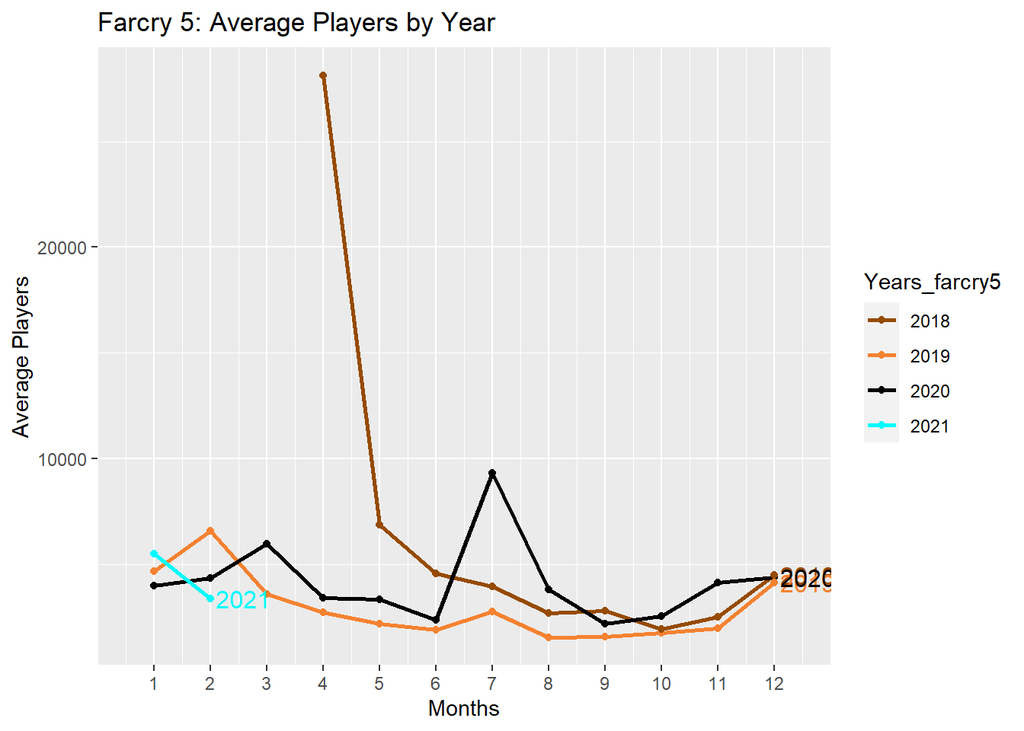

```r
Years_farcry5 <- as.factor(g_farcry5$year)
ggplot(g_farcry5,aes(x = number_of_month,y = avg, group = year, color = Years_farcry5)) +
geom_line(size = 1) +
geom_point()+
scale_x_continuous(breaks = seq(1, 12, by = 1),expand=c(0, 1))+
geom_dl(aes(label = year), method = list(dl.trans(x = x + 0.1), "last.points", cex = 1)) +
scale_colour_manual(values=c("#964B00","#f58231","#030000", "#00FBFE", "#3cb44b", "#FF0004", "#4363d8", "#911eb4", "#f032e6", "#a9a9a9" )) +
  xlab("Months")+
  ylab("Average Players") +
  labs(title = "Farcry 5: Average Players by Year")
```

```r
g_cyberpunk <- games %>%
  filter(gamename == "Cyberpunk 2077") %>%
  filter(year %in% c(2012:2021)) %>%
  mutate(label = if_else(number_of_month == max(number_of_month), as.character(year), NA_character_))
g_cyberpunk
```

| gamename | year | number_of_month | month | avg | gain | peak | avg_peak_perc | label |
| --- | --- | --- | --- | --- | --- | --- | --- | --- |
| Cyberpunk 2077 | 2021 | 1 | January | 82146.66 | -250248.99 | 225670 | 36.4012% | NA |
| Cyberpunk 2077 | 2021 | 2 | February | 24704.84 | -57441.83 | 47115 | 52.4352% | NA |
| Cyberpunk 2077 | 2020 | 12 | December | 332395.65 | NA | 830387 | 40.029% | 2020 |

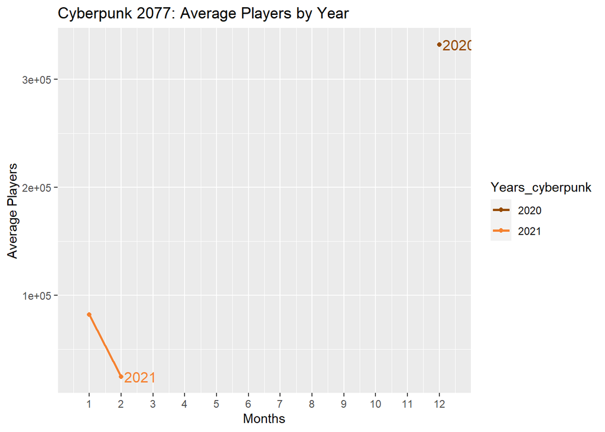

```r
Years_cyberpunk <- as.factor(g_cyberpunk$year)
ggplot(g_cyberpunk,aes(x = number_of_month,y = avg, group = year, color = Years_cyberpunk)) +
geom_line(size = 1) +
geom_point()+
scale_x_continuous(breaks = seq(1, 12, by = 1),expand=c(0, 1))+
geom_dl(aes(label = year), method = list(dl.trans(x = x + 0.1), "last.points", cex = 1)) +
scale_colour_manual(values=c("#964B00","#f58231","#030000", "#00FBFE", "#3cb44b", "#FF0004", "#4363d8", "#911eb4", "#f032e6", "#a9a9a9" )) +
  xlab("Months")+
  ylab("Average Players") +
  labs(title = "Cyberpunk 2077: Average Players by Year")
```

```r
g_girl <- games %>%
  filter(gamename == "Hentai Girl") %>%
  filter(year %in% c(2012:2021)) %>%
  mutate(label = if_else(number_of_month == max(number_of_month), as.character(year), NA_character_))
g_girl
```

| gamename | year | number_of_month | month | avg | gain | peak | avg_peak_perc | label |
| --- | --- | --- | --- | --- | --- | --- | --- | --- |
| Hentai Girl | 2021 | 1 | January | 26.60 | -0.43 | 94 | 28.2979% | NA |
| Hentai Girl | 2021 | 2 | February | 23.02 | -3.59 | 64 | 35.9688% | NA |
| Hentai Girl | 2020 | 1 | January | 20.08 | 4.04 | 165 | 12.1697% | NA |
| Hentai Girl | 2020 | 2 | February | 13.72 | -6.36 | 35 | 39.2% | NA |
| Hentai Girl | 2020 | 3 | March | 13.41 | -0.31 | 50 | 26.82% | NA |
| Hentai Girl | 2020 | 4 | April | 21.83 | 8.42 | 85 | 25.6824% | NA |
| Hentai Girl | 2020 | 5 | May | 16.66 | -5.17 | 32 | 52.0625% | NA |
| Hentai Girl | 2020 | 6 | June | 27.09 | 10.43 | 244 | 11.1025% | NA |
| Hentai Girl | 2020 | 7 | July | 26.11 | -0.98 | 243 | 10.7449% | NA |
| Hentai Girl | 2020 | 8 | August | 18.24 | -7.86 | 40 | 45.6% | NA |

[output cut: 21 more lines]

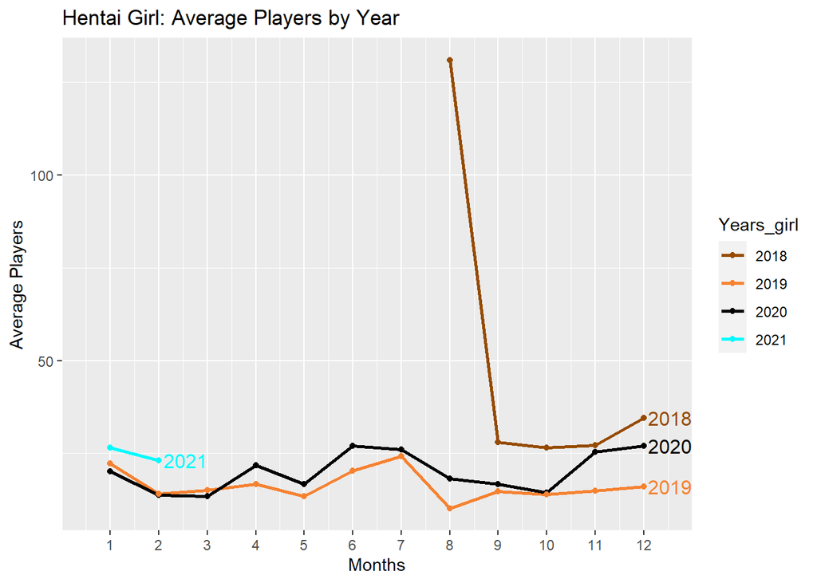

```r
Years_girl <- as.factor(g_girl$year)
ggplot(g_girl,aes(x = number_of_month,y = avg, group = year, color = Years_girl)) +
geom_line(size = 1) +
geom_point()+
scale_x_continuous(breaks = seq(1, 12, by = 1),expand=c(0, 1))+
geom_dl(aes(label = year), method = list(dl.trans(x = x + 0.1), "last.points", cex = 1)) +
scale_colour_manual(values=c("#964B00","#f58231","#030000", "#00FBFE", "#3cb44b", "#FF0004", "#4363d8", "#911eb4", "#f032e6", "#a9a9a9" )) +
  xlab("Months")+
  ylab("Average Players") +
  labs(title = "Hentai Girl: Average Players by Year")
```

> This data shows that singleplayer titles seem to have a drastic fall off in their player base following the launch of the game. This most likely occurs because once someone beats a single player game they are less likely to return to it. This can also be attributed to the fact that multiplayer/esports games are usally continually updated with new content single player game typically are less likely to receive these updates consistently.

## **Question 2: Is the Steam platform effected by seasonality?**

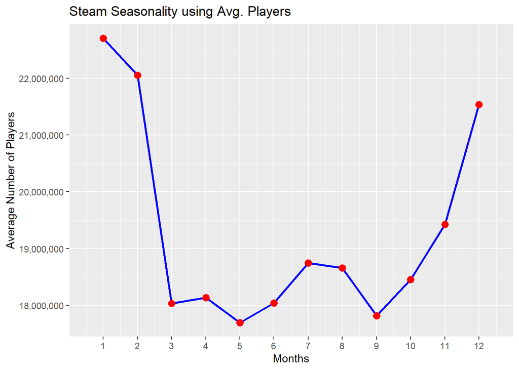

```r
games_seasons <- games %>%
  filter(year %in% c(2012:2021)) %>%
  group_by(number_of_month) %>%
  summarise(avg_month_sum = sum(avg))
ggplot(data = games_seasons) +
  geom_line(aes(x = number_of_month, y = avg_month_sum),color = "blue", size = 1) +
  geom_point(aes(x = number_of_month, y = avg_month_sum),color = "red", size = 3)+
  scale_x_continuous(breaks = seq(1, 12, by = 1),expand=c(0, 1)) +
  scale_y_continuous(labels = comma) +
  xlab("Months")+
  ylab("Average Number of Players") +
  labs(title = "Steam Seasonality using Avg. Players")
```

```r
games_seasons
```

| number_of_month | avg_month_sum |
| --- | --- |
| 1 | 22707611 |
| 2 | 22052744 |
| 3 | 18031242 |
| 4 | 18134756 |
| 5 | 17698268 |
| 6 | 18040156 |
| 7 | 18745631 |
| 8 | 18657067 |
| 9 | 17816143 |
| 10 | 18453935 |

[output cut: 2 more lines]

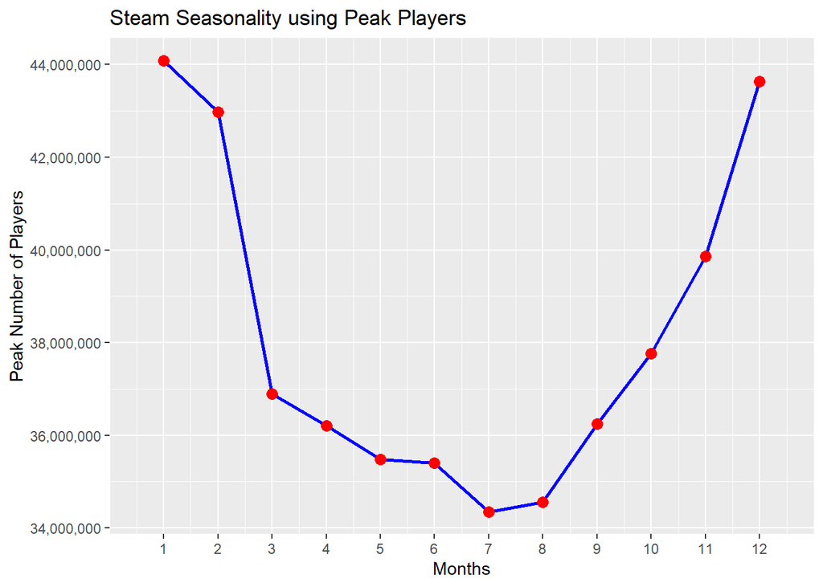

```r
games_seasons_pk <- games %>%
  filter(year %in% c(2012:2021)) %>%
  group_by(number_of_month) %>%
  summarise(peak_month_sum = sum(peak))
ggplot(data = games_seasons_pk) +
  geom_line(aes(x = number_of_month, y = peak_month_sum),color = "blue", size = 1) +
  geom_point(aes(x = number_of_month, y = peak_month_sum),color = "red", size = 3)+
  scale_x_continuous(breaks = seq(1, 12, by = 1),expand=c(0, 1)) +
  scale_y_continuous(labels = comma) +
  xlab("Months")+
  ylab("Peak Number of Players") +
  labs(title = "Steam Seasonality using Peak Players")
```

```r
games_seasons_pk
```

| number_of_month | peak_month_sum |
| --- | --- |
| 1 | 44090490 |
| 2 | 42979104 |
| 3 | 36888970 |
| 4 | 36206347 |
| 5 | 35480506 |
| 6 | 35398973 |
| 7 | 34349937 |
| 8 | 34555189 |
| 9 | 36242021 |
| 10 | 37767829 |

[output cut: 2 more lines]

## Question 3: What does the growth of Steam platform look like from 2012 - 2021?

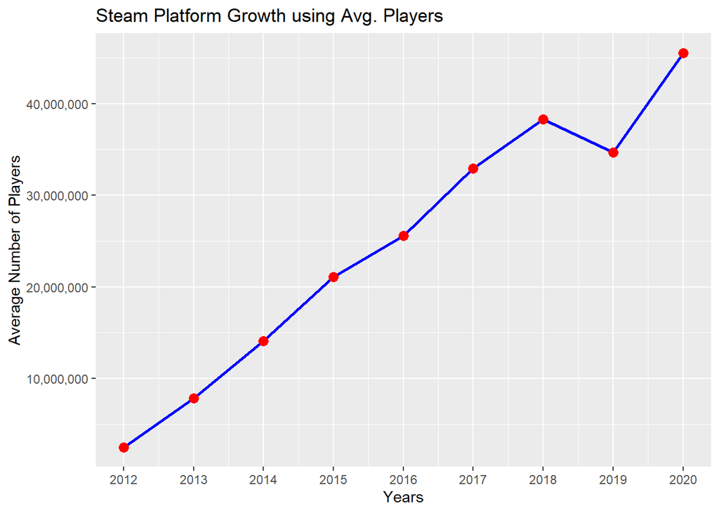

```r
games_user_growth <- games %>%
  filter(year %in% c(2012:2020)) %>%
  group_by(year) %>%
  summarise(avg_month_all_years = sum(avg))
ggplot(data = games_user_growth) +
  geom_line(aes(x = year, y = avg_month_all_years),color = "blue", size = 1) +
  geom_point(aes(x = year, y = avg_month_all_years),color = "red", size = 3) +
  scale_x_continuous(breaks = seq(2012, 2020, by = 1)) +
  scale_y_continuous(labels = comma) +
  xlab("Years")+
  ylab("Average Number of Players") +
  labs(title = "Steam Platform Growth using Avg. Players")
```

```r
games_user_growth
```

| year | avg_month_all_years |
| --- | --- |
| 2012 | 2506774 |
| 2013 | 7828706 |
| 2014 | 14113007 |
| 2015 | 21097660 |
| 2016 | 25560219 |
| 2017 | 32953695 |
| 2018 | 38275440 |
| 2019 | 34683735 |
| 2020 | 45546334 |

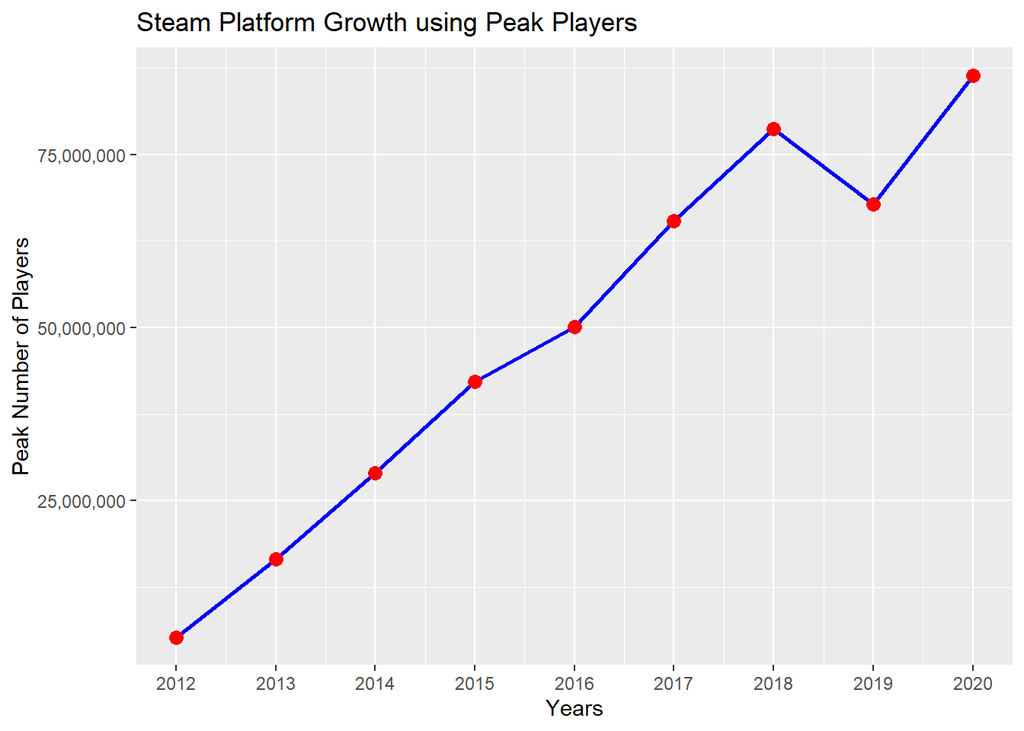

```r
games_user_growth_pk <- games %>%
  filter(year %in% c(2012:2020)) %>%
  group_by(year) %>%
  summarise(peak_month_all_years = sum(peak))
ggplot(data = games_user_growth_pk) +
  geom_line(aes(x = year, y = peak_month_all_years),color = "blue", size = 1) +
  geom_point(aes(x = year, y = peak_month_all_years),color = "red", size = 3) +
  scale_x_continuous(breaks = seq(2012, 2020, by = 1)) +
  scale_y_continuous(labels = comma) +
  xlab("Years")+
  ylab("Peak Number of Players") +
  labs(title = "Steam Platform Growth using Peak Players")
```

```r
games_user_growth_pk
```

| year | peak_month_all_years |
| --- | --- |
| 2012 | 5304037 |
| 2013 | 16606017 |
| 2014 | 28962769 |
| 2015 | 42233710 |
| 2016 | 50053767 |
| 2017 | 65378451 |
| 2018 | 78678434 |
| 2019 | 67835438 |
| 2020 | 86423985 |

> Looking at the data we can see that the Steam platform has had relatively consistent growth from 2012 to 2020. However can see the only time Steam has a drop in users was from 2018 to 2019. We suspect this to be related to the rise of other online games market places such as the EPIC Games store and the popularity of Fortnite at the time. In November of 2018 Fortnite hit a with 8.3 million concurrent players. We suspect that the popuarity of Fortnite combined with the fact that it was not on Steam is ultimately what caused the dip in players from 2018-2019.

## **Question 4: The number of relevant titles published to the Steam platform from 2012 - 2021?**

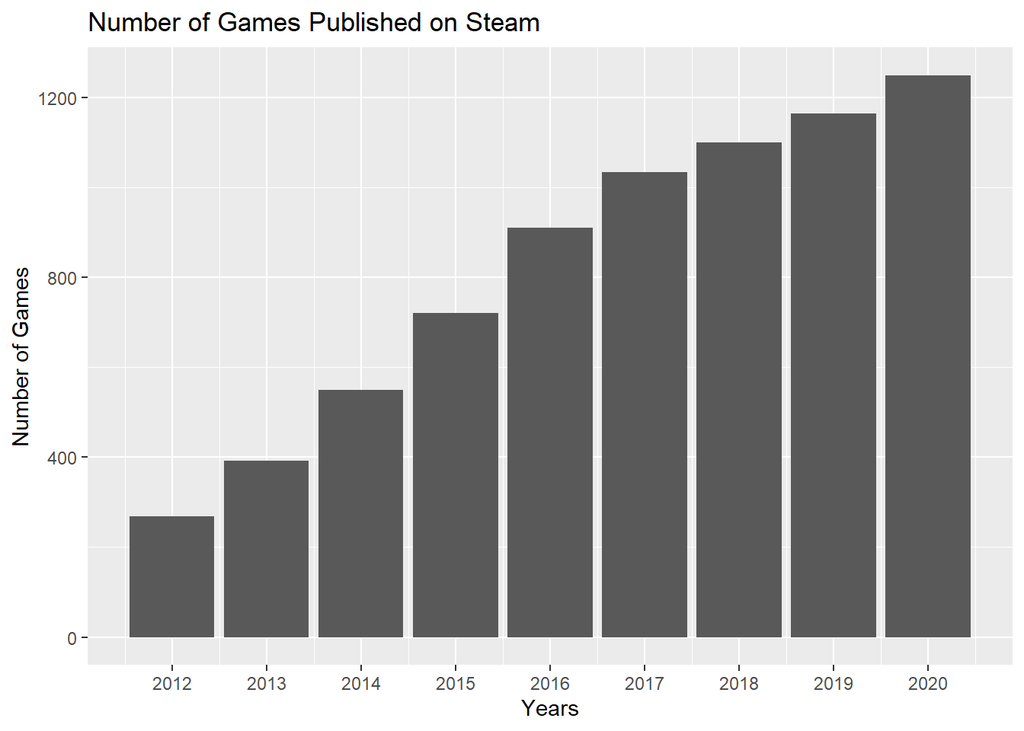

```r
g_without_2021 <- games %>%
  filter(number_of_month == 12, year %in% 2012:2020)

g_added <- g_without_2021 %>%
ggplot()+
  geom_bar(aes(x = year))+
  scale_x_continuous(breaks = seq(2012, 2020, by = 1)) +
  xlab("Years")+
  ylab("Number of Games") +
  labs(title = "Number of Games Published on Steam")

g_added
```

## **Question 5: Whats the change in new relevant titles being published to Steam from 2012 - 2021?**

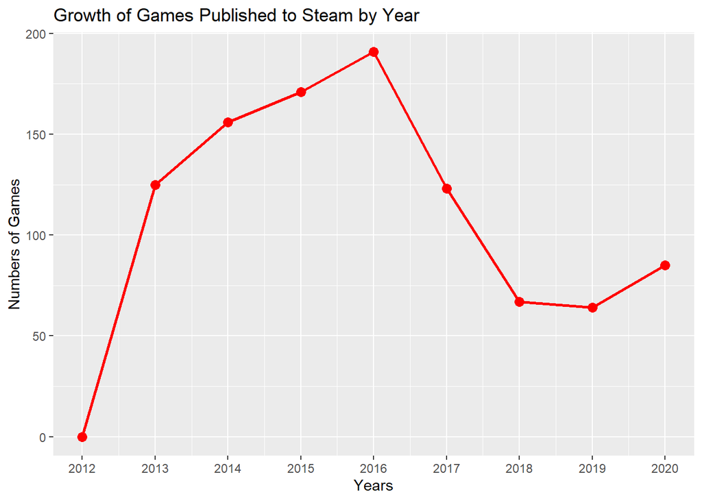

```r
g_added_count <- g_without_2021 %>%
  count(year)

grow_diff_titles <- c(268,268,393,549,720,911,1034,1101,1165)

g_added_count$differ <- grow_diff_titles

g_added_count <- g_added_count %>%
  mutate(subtracted = n - differ)

g_added_count %>%
  ggplot() +
  geom_line(aes(x = year, y = subtracted, group = 1), size = 1, color = "red")+
  geom_point(aes(x = year, y = subtracted, group = 1), size = 3, color = "red")+
  scale_x_continuous(breaks = seq(2012, 2020, by = 1)) +
  xlab("Years")+
  ylab("Numbers of Games") +
  labs(title = "Growth of Games Published to Steam by Year")
```

```r
g_added_count
```

| year | n | differ | subtracted |
| --- | --- | --- | --- |
| 2012 | 268 | 268 | 0 |
| 2013 | 393 | 268 | 125 |
| 2014 | 549 | 393 | 156 |
| 2015 | 720 | 549 | 171 |
| 2016 | 911 | 720 | 191 |
| 2017 | 1034 | 911 | 123 |
| 2018 | 1101 | 1034 | 67 |
| 2019 | 1165 | 1101 | 64 |
| 2020 | 1250 | 1165 | 85 |

> When analyzing this data we are looking at what we consider to be relevant titles published on the Steam platform. Anyone can publish their game on Steam and as of 2020 their were nearly 50,000 titles published on the platform. The data utilized in the data set is pulled from a data set that foucses on games that are actually played. When looking at the graphs we can see that the game library on Steam has been increasing over the years however we can also see that there was a large dip in the number of relevant games published to the platform between 2016 and 2018

# Data Analysis Questions

## what game had the best avg players proformance on steam?

```r
games %>%
  filter(avg == max(avg))
```

| gamename | year | number_of_month | month | avg | gain | peak | avg_peak_perc |
| --- | --- | --- | --- | --- | --- | --- | --- |
| PLAYERUNKNOWN'S BATTLEGROUNDS | 2018 | 1 | January | 1584887 | 148728.3 | 3236027 | 48.9763% |

## What game had the most peak players in steam history?

```r
games %>%
  filter(peak == max(peak))
```

| gamename | year | number_of_month | month | avg | gain | peak | avg_peak_perc |
| --- | --- | --- | --- | --- | --- | --- | --- |
| PLAYERUNKNOWN'S BATTLEGROUNDS | 2018 | 1 | January | 1584887 | 148728.3 | 3236027 | 48.9763% |

## Which game had the highest gain in players from the previous month

```r
games %>%
  drop_na(gain) %>%
  filter(gain == max(gain))
```

| gamename | year | number_of_month | month | avg | gain | peak | avg_peak_perc |
| --- | --- | --- | --- | --- | --- | --- | --- |
| PLAYERUNKNOWN'S BATTLEGROUNDS | 2017 | 10 | October | 1086639 | 426446.1 | 2390946 | 45.4481% |

> Playersunknown Battlegrounds has had the highest peak and avg players as well as greatest gain from the prior month in all of steam history.

## Which game has had the biggest loss of players from one month to the next in steam history?

```r
games %>%
  drop_na(gain) %>%
  filter(gain == min(gain))
```

| gamename | year | number_of_month | month | avg | gain | peak | avg_peak_perc |
| --- | --- | --- | --- | --- | --- | --- | --- |
| Cyberpunk 2077 | 2021 | 1 | January | 82146.66 | -250249 | 225670 | 36.4012% |

> This makes sense considering cyberpunk was badly reviewed after the released. The game was filled with bugs that made the game hard to enjoy so a lot of people returned the game as well.